# Spatio-temporal disease mapping with `R-INLA`

Julien Riou

2024-03-07

# 1 Mixed models in `R-INLA`

## 1.1 Fixed effects

Fixed effects are often used to quantify the link between the outcome and covariates of central interest, thought to systematically affect the outcome in the same way. A simple example would be to study how is sex associated with the number of reported cases of influenza in the obligatory system. To do that, we can start by aggregating cases by year.

```r
flu_year_ch_sex = flu %>%
  dplyr::filter(georegion=="CHFL", agegroup=="all", sex %in% c("male","female"), type=="all") %>%
  dplyr::group_by(sex,year) %>%
  dplyr::summarise(value=sum(value),pop=max(pop),.groups="drop")
```

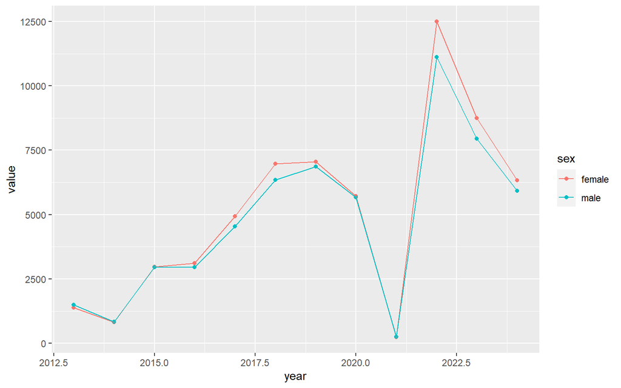

```r
ggplot(flu_year_ch_sex, aes(x=year,y=value,colour=sex,group=sex)) +
  geom_point() +
  geom_line()
```

We see a tendency towards more reported cases among women. We can measure the average difference with Poisson regression. This assumes that the number of reported cases on any year follows a Poisson distribution with mean $\lambda_i$:
$$y_i \sim \text{Poisson}(\lambda_i) \\
\log\lambda_i = \alpha + \beta X_i \\
\alpha \sim \mathcal{N}(0,10)\\
\beta \sim \mathcal{N}(0,10)$$
If we set $X_i$ as `0` for women and `1` for men, this means that the expected number of cases will have mean $\exp(\alpha)$ for women and $\exp(\alpha+\beta)$ for men. In other words, the incidence ratio between men and women will be:

$$IR =
\frac{\exp(\alpha+\beta)}{\exp(\alpha)}
= \frac{\exp(\alpha)\times\exp(\beta)}{\exp(\alpha)} =
\exp(\beta).$$

```r
m_year_sex_ch1 = inla(value ~ 1 + sex,
                      data=flu_year_ch_sex,
                      family = "poisson",
                      control.fixed = list(mean.intercept=0, prec.intercept=1/10^2, mean=0, prec=1/10^2))
summary(m_year_sex_ch1)
```

```
##
## Call:
##    c("inla.core(formula = formula, family = family, contrasts = contrasts,
##    ", " data = data, quantiles = quantiles, E = E, offset = offset, ", "
##    scale = scale, weights = weights, Ntrials = Ntrials, strata = strata,
##    ", " lp.scale = lp.scale, link.covariates = link.covariates, verbose =
##    verbose, ", " lincomb = lincomb, selection = selection, control.compute
##    = control.compute, ", " control.predictor = control.predictor,
##    control.family = control.family, ", " control.inla = control.inla,
##    control.fixed = control.fixed, ", " control.mode = control.mode,
##    control.expert = control.expert, ", " control.hazard = control.hazard,
##    control.lincomb = control.lincomb, ", " control.update =
##    control.update, control.lp.scale = control.lp.scale, ", "
##    control.pardiso = control.pardiso, only.hyperparam = only.hyperparam,
##    ", " inla.call = inla.call, inla.arg = inla.arg, num.threads =
##    num.threads, ", " keep = keep, working.directory = working.directory,
##    silent = silent, ", " inla.mode = inla.mode, safe = FALSE, debug =
##    debug, .parent.frame = .parent.frame)" )
## Time used:
##     Pre = 2.96, Running = 0.931, Post = 0.151, Total = 4.04
## Fixed effects:
##               mean    sd 0.025quant 0.5quant 0.975quant   mode kld
## (Intercept)  8.530 0.004      8.522    8.530      8.538  8.530   0
## sexmale     -0.066 0.006     -0.077   -0.066     -0.054 -0.066   0
##
## Marginal log-Likelihood:  -29032.94
##  is computed
## Posterior summaries for the linear predictor and the fitted values are computed
## (Posterior marginals needs also 'control.compute=list(return.marginals.predictor=TRUE)')
```

The rows `(Intercept)` and `sexmale` provide summary statistics for the posterior distribution of $\alpha$ and $\beta$. But as said before, what we are interested in (because it has a real-life interpretation) are the exponentials of $\alpha$ and $\beta$.

```r
exp(m_year_sex_ch1$summary.fixed[,c("mean","0.025quant","0.975quant")])
```

```
##                     mean  0.025quant   0.975quant
## (Intercept) 5063.0344924 5022.932550 5103.4565999
## sexmale        0.9364855    0.925838    0.9472555
```

These results can be interpreted as follows: we expect on average 5063 cases of influenza in women per year (95% credible interval: 5023 to 5103), and we expect the number of male cases to be 6% lower (5% to 7%) than the number of female cases. This is the type of approach where fixed effects shine.

## 1.2 Random effects

Random effects relate to situations where model parameters are considered as random variables. In practice, this is used when we effect an effect to be heterogeneous across different groups, generally more than 5 or 6 groups. Instead of measuring the effect in each group compared to a reference group (e.g., males compared to females), we consider the distribution of effects, generally around zero, with a certain standard deviation or precision (for normally-distributed which are the most common). In this context, the standard deviation is called an **hyperparameter** and can be estimated from data. The standard deviation can be interpreted as a measure of the heterogeneity of the effect across groups. If we go back to the example of the Poisson regression above, the formula becomes:
$$y_i \sim \text{Poisson}(\lambda_i) \\
\log\lambda_i = \alpha + \beta_i \\
\alpha \sim \mathcal{N}(0,10) \\
\beta_i \sim \mathcal{N}(0,\tau\Sigma) \\
\tau \sim \mathcal{Gamma}(1.0.00005) \\$$
The formula is slightly more complex, with the hyperparameter $\tau$ (the precision) that must be given a prior distribution. We won’t dig into how to choose prior distributions for scale parameters here (there are a few possible approaches based on heuristics or simulation (Gabry et al. 2019; Stan development team 2024)). In `INLA` it is generally fine to stick to the (non-informative) defaults.

## 1.3 I.i.d. random effects

The type of random effect is defined by the matrix $\Sigma$. In the simplest case, $\Sigma$ is an identity matrix, so that all $\beta_i$ are **independent and identically distributed** (i.i.d). We can try this with the gender example, even if it would not make so much sense to use random effects for two groups.

```r
m_year_sex_ch2 = inla(value ~ 1 + f(sex, model="iid", precision = c(1, 0.00005)),
                      data=flu_year_ch_sex,
                      family = "poisson",
                      control.fixed = list(mean.intercept=0, prec.intercept=1/10^2))
summary(m_year_sex_ch2)
```

```
##
## Call:
##    c("inla.core(formula = formula, family = family, contrasts = contrasts,
##    ", " data = data, quantiles = quantiles, E = E, offset = offset, ", "
##    scale = scale, weights = weights, Ntrials = Ntrials, strata = strata,
##    ", " lp.scale = lp.scale, link.covariates = link.covariates, verbose =
##    verbose, ", " lincomb = lincomb, selection = selection, control.compute
##    = control.compute, ", " control.predictor = control.predictor,
##    control.family = control.family, ", " control.inla = control.inla,
##    control.fixed = control.fixed, ", " control.mode = control.mode,
##    control.expert = control.expert, ", " control.hazard = control.hazard,
##    control.lincomb = control.lincomb, ", " control.update =
##    control.update, control.lp.scale = control.lp.scale, ", "
##    control.pardiso = control.pardiso, only.hyperparam = only.hyperparam,
##    ", " inla.call = inla.call, inla.arg = inla.arg, num.threads =
##    num.threads, ", " keep = keep, working.directory = working.directory,
##    silent = silent, ", " inla.mode = inla.mode, safe = FALSE, debug =
##    debug, .parent.frame = .parent.frame)" )
## Time used:
##     Pre = 2.77, Running = 0.842, Post = 0.15, Total = 3.76
## Fixed effects:
##              mean    sd 0.025quant 0.5quant 0.975quant  mode   kld
## (Intercept) 8.497 0.027      8.441    8.497      8.552 8.497 0.007
##
## Random effects:
##   Name     Model
##     sex IID model
##
## Model hyperparameters:
##                      mean      sd 0.025quant 0.5quant 0.975quant   mode
## Precision for sex 1425.28 1208.34     107.79  1103.65    4602.08 439.47
##
## Marginal log-Likelihood:  -29030.83
##  is computed
## Posterior summaries for the linear predictor and the fitted values are computed
## (Posterior marginals needs also 'control.compute=list(return.marginals.predictor=TRUE)')
```

The intercept didn’t change much. Since it’s not a fixed effect anymore, the effect of gender does not appear directly, but can be extracted from the model object.

```r
m_year_sex_ch2$summary.random$sex
```

```
##       ID        mean         sd  0.025quant   0.5quant 0.975quant        mode
## 1 female  0.03201385 0.02677152 -0.02287939  0.0317517 0.08818960  0.03179427
## 2   male -0.03189194 0.02676948 -0.08789892 -0.0316735 0.02316612 -0.03168405
##           kld
## 1 0.007157470
## 2 0.007155141
```

It’s interesting to note that instead of having an effect in males compared to females of `-0.066`, we find basically half of this effect on each side of zero: `-0.032` in males and `+0.032` in females. Random effects are not defined relatively to each other, but relatively to a mean set at zero. And as before, it is easier to interpret the exponents.

```r
exp(m_year_sex_ch2$summary.random$sex[,c("mean","0.025quant","0.975quant")])
```

```
##        mean 0.025quant 0.975quant
## 1 1.0325318  0.9773804   1.092195
## 2 0.9686112  0.9158535   1.023437
```

Compared to an “average gender”, there are 3% more female cases and 3% less male cases. Of course in the case of gender the average does not make so much sense (although), but it would work well for other variables (average country, average canton, average family, etc.). Indeed, random effects are often used for building nested **hierarchies** (e.g., canton within country, or classroom within school).

## 1.4 Fixed or random?

Sometimes it’s not so clear whether a variable should be included as a fixed or random effect. Things to consider include the number of groups (more or fewer than 5-6) and the objective (do we look for an average effect or do we want to compare groups to each other). It is also possible to try both and see which one fits the data best. There are many tools for doing such **model comparisons** (in many situations, not just this one). Classically people have been using the Akaike Information Criterion (AIC). This indicator is based on information theory, and is comparatively **lower** for models that minimize information loss. Intuitively, it provides a balance between how close the model is to the data with how complex the model is (i.e. how many parameters it has). Other, more modern criteria exist, such as the WAIC (for widely applicable information criterion). It works in a similar way (lower is better) and is available in `INLA`. We just have to mention it in the call.

```r
m_year_sex_ch1 = inla(value ~ 1 + sex,
                      data=flu_year_ch_sex,
                      family = "poisson",
                      control.fixed = list(mean.intercept=0, prec.intercept=1/10^2, mean=0, prec=1/10^2),
                      control.compute = list(waic = TRUE))
m_year_sex_ch2 = inla(value ~ 1 + f(sex, model="iid", precision = c(1, 0.01)),
                      data=flu_year_ch_sex,
                      family = "poisson",
                      control.fixed = list(mean.intercept=0, prec.intercept=1/10^2),
                      control.compute = list(waic = TRUE))
m_year_sex_ch1$waic$waic
```

```
## [1] 10238
```

```r
m_year_sex_ch2$waic$waic
```

```
## [1] 10341.08
```

By computing the WAIC for the models with gender included as a fixed or random effect, we see that the former has a lower WAIC than the latter, so than it should be favored.

## 1.5 First spatial model

If we go back to the example and instead of gender look at canton, we can try to use an i.i.d. random effect to build our first spatial model.

```r
flu_year_ch_canton = flu %>%
  filter(georegion_type=="canton", georegion!="unknown", agegroup=="all", sex=="all", type=="all") %>%
  group_by(georegion,year) %>%
  summarise(value=sum(value),pop=max(pop),.groups="drop")
```

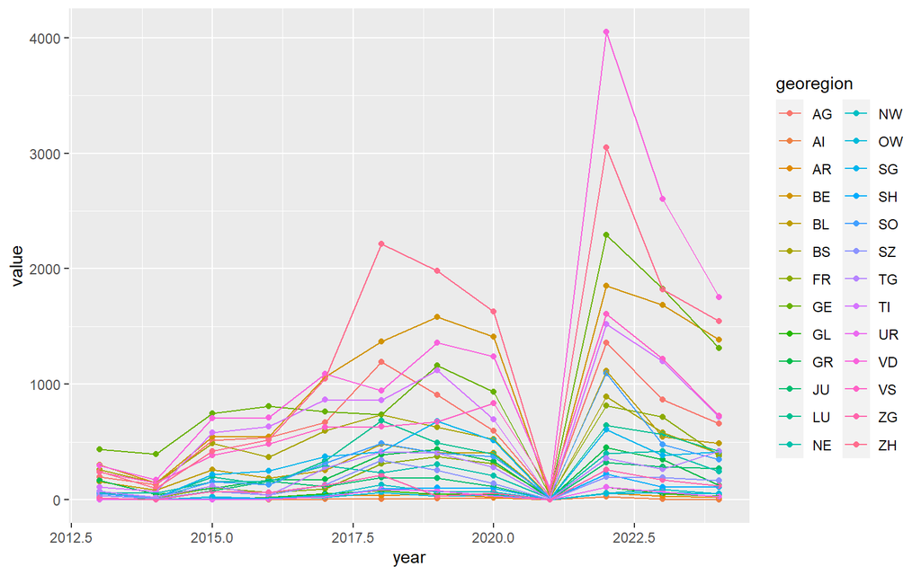

```r
ggplot(flu_year_ch_canton, aes(x=year,y=value,colour=georegion,group=georegion)) +
  geom_point() +
  geom_line()
```

Of course, since the populations of each canton are so different, it makes more sense to not use the raw number and scale by population.

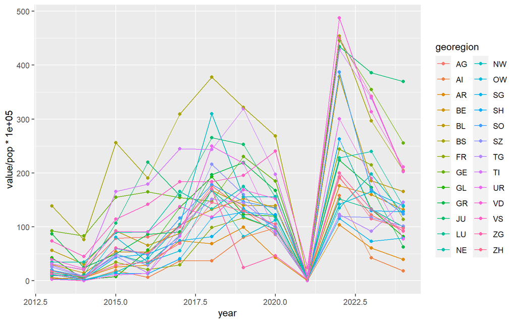

```r
ggplot(flu_year_ch_canton, aes(x=year,y=value/pop*1e5,colour=georegion,group=georegion)) +
  geom_point() +
  geom_line()
```

In the model, this scaling can be done by using an **offset**. If we go back to the formula for the Poisson regression model with random effects, we can add the offset $O_i$ so that it acts as a denominator.
$$\log\lambda_i = \alpha + \beta_i + \log O_i \\
\log\lambda_i - \log O_i = \alpha + \beta_i \\
\log\frac{\lambda_i}{O_i} = \alpha + \beta_i$$
This way, we can still use Poisson regression (that is adapted to count data and would not work with incidence rates).

Let us focus on one year, for instance 2022.

```r
flu_year_ch_canton = flu_year_ch_canton %>%
  filter(year==2022)
```

The model is written as follows:

```r
m_canton_ch1 = inla(value ~ 1 +
                      f(georegion, model="iid", precision = c(1, 0.01)),
                    offset = log(pop),
                    data=flu_year_ch_canton,
                    family = "poisson",
                    control.fixed = list(mean.intercept=0, prec.intercept=1/10^2),
                    control.compute = list(waic=TRUE))
summary(m_canton_ch1)
```

```
##
## Call:
##    c("inla.core(formula = formula, family = family, contrasts = contrasts,
##    ", " data = data, quantiles = quantiles, E = E, offset = offset, ", "
##    scale = scale, weights = weights, Ntrials = Ntrials, strata = strata,
##    ", " lp.scale = lp.scale, link.covariates = link.covariates, verbose =
##    verbose, ", " lincomb = lincomb, selection = selection, control.compute
##    = control.compute, ", " control.predictor = control.predictor,
##    control.family = control.family, ", " control.inla = control.inla,
##    control.fixed = control.fixed, ", " control.mode = control.mode,
##    control.expert = control.expert, ", " control.hazard = control.hazard,
##    control.lincomb = control.lincomb, ", " control.update =
##    control.update, control.lp.scale = control.lp.scale, ", "
##    control.pardiso = control.pardiso, only.hyperparam = only.hyperparam,
##    ", " inla.call = inla.call, inla.arg = inla.arg, num.threads =
##    num.threads, ", " keep = keep, working.directory = working.directory,
##    silent = silent, ", " inla.mode = inla.mode, safe = FALSE, debug =
##    debug, .parent.frame = .parent.frame)" )
## Time used:
##     Pre = 3.08, Running = 1.07, Post = 0.259, Total = 4.41
## Fixed effects:
##               mean    sd 0.025quant 0.5quant 0.975quant   mode kld
## (Intercept) -6.059 0.097     -6.252   -6.059     -5.867 -6.059   0
##
## Random effects:
##   Name     Model
##     georegion IID model
##
## Model hyperparameters:
##                         mean   sd 0.025quant 0.5quant 0.975quant mode
## Precision for georegion 4.42 1.23       2.36     4.31       7.16 4.08
##
## Watanabe-Akaike information criterion (WAIC) ...: 250.69
## Effective number of parameters .................: 13.08
##
## Marginal log-Likelihood:  -190.83
##  is computed
## Posterior summaries for the linear predictor and the fitted values are computed
## (Posterior marginals needs also 'control.compute=list(return.marginals.predictor=TRUE)')
```

We can look at the distribution of the canton-specific effect $\beta_i$ (centered around zero).

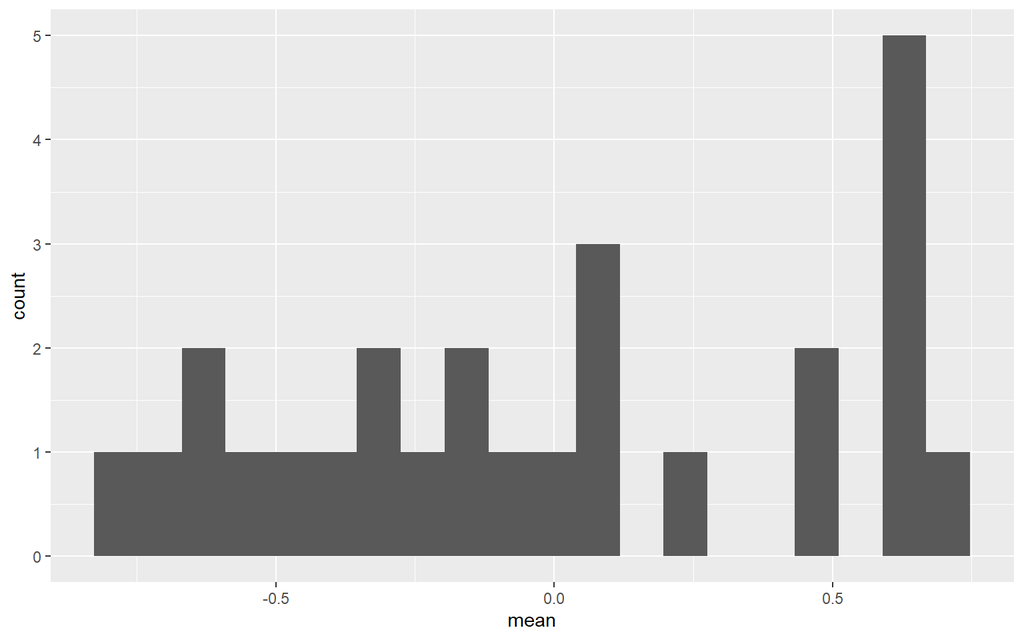

```r
m_canton_ch1$summary.random$georegion %>%
  ggplot(aes(x=mean)) +
  geom_histogram(bins=20)
```

Because we added the offset, what we actually model are incidence rates, so that $\exp(\beta_i)$ can be interpreted as **incidence rate ratios** (IRR). The IRRs are interpreted with reference to an hypothetical “average canton”, for whom the IRR would be 1. We see a lot of variation across cantons, from both Appenzell Ausserrhoden to Vaud.

```r
irr = m_canton_ch1$summary.random$georegion %>%
  select(ID,mean,`0.025quant`,`0.975quant`) %>%
  mutate(across(2:4,exp)) %>%
  arrange(-mean)
irr
```

```
##    ID      mean 0.025quant 0.975quant
## 1  VD 2.0847006  1.7169428  2.5348055
## 2  BS 1.9345582  1.5813673  2.3708217
## 3  VS 1.9243979  1.5797677  2.3478689
## 4  GE 1.9042766  1.5657448  2.3194217
## 5  JU 1.8411504  1.4806996  2.2946808
## 6  TI 1.8323727  1.5037232  2.2363081
## 7  SO 1.6521795  1.3528249  2.0209303
## 8  BL 1.6154603  1.3229448  1.9756939
## 9  UR 1.2668419  0.9775684  1.6445708
## 10 SH 1.1199782  0.8912165  1.4091604
## 11 GL 1.1148854  0.8590253  1.4486380
## 12 FR 1.0432318  0.8518009  1.2791916
## 13 NE 0.9758401  0.7884685  1.2089169
## 14 GR 0.9565669  0.7746105  1.1824098
## 15 ZG 0.8555352  0.6839889  1.0706608
## 16 ZH 0.8262447  0.6799271  1.0052343
## 17 AG 0.8197798  0.6721612  1.0008804
## 18 BE 0.7545313  0.6197216  0.9196558
## 19 AI 0.7066760  0.4793875  1.0379445
## 20 LU 0.6511605  0.5300852  0.8003440
## 21 OW 0.6261468  0.4595462  0.8508035
## 22 NW 0.5958015  0.4405084  0.8035152
## 23 TG 0.5309320  0.4277006  0.6588857
## 24 SZ 0.5175846  0.4097706  0.6529614
## 25 SG 0.4984711  0.4054210  0.6129896
## 26 AR 0.4675580  0.3447448  0.6312243
```

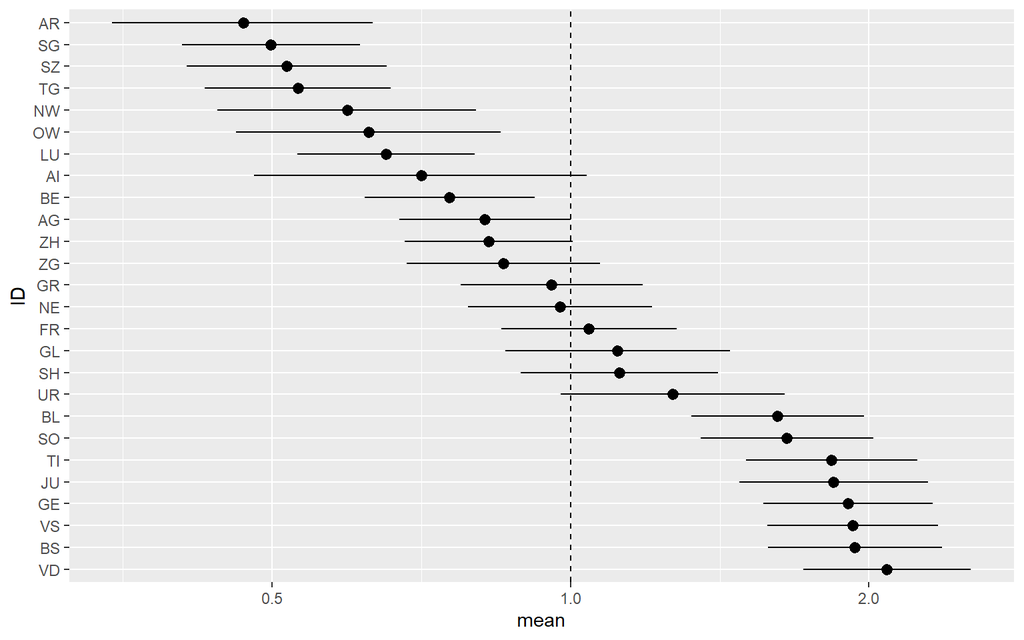

```r
irr %>%
  ggplot(aes(x=ID,y=mean,ymin=`0.025quant`,ymax=`0.975quant`)) +
  geom_pointrange() +
  geom_hline(yintercept=1,linetype=2) +
  scale_x_discrete(limits=irr$ID) +
  scale_y_log10() +
  coord_flip()
```

## Exercice

Fit a model of reported influenza cases in 2022 by canton using fixed effects, and compare with model `m_canton_ch1`. Compare the reported incidence rate of influenza across age groups.

# References

Gabry, Jonah, Daniel Simpson, Aki Vehtari, Michael Betancourt, and Andrew Gelman. 2019. “Visualization in Bayesian Workflow.” *Journal of the Royal Statistical Society: Series A (Statistics in Society)* 182 (2): 389–402. https://doi.org/https://doi.org/10.1111/rssa.12378.

Stan development team. 2024. “Prior Choice Recommendations.” https://github.com/stan-dev/stan/wiki/Prior-Choice-Recommendations.